# Cars4U Project

By: Glen A Patterson

Date: 9-1-2022

## Problem Statment:

Develop a pricing model that can effectively predict the price of used cars and can help the business find profitable strategies using differential pricing for their used cars.

## Objective:

- To explore and visualize the dataset using Univariate and Bivariate analysis.
- Find key meaningful observations on the relationship between variables.
- Build a linear regression model to predict the prices of used cars.
- Generate a set of insights and recommendations that will help the business.

## Data Dictionary:

1. S.No.: Serial number
2. Name: Name of the car which includes brand name and model name
3. Location: Location in which the car is being sold or is available for purchase (cities)
4. Year: Manufacturing year of the car
5. Kilometers_driven: The total kilometers (a unit used to measure length or distance) driven in the car by the previous owner(s)
6. Fuel_Type: The type of fuel used by the car (Petrol, Diesel, Electric, CNG, LPG)
7. Transmission: The type of transmission used by the car (Automatic/Manual)
8. Owner: Type of ownership
9. Mileage: The standard mileage offered by the car company in kmpl or km/kg
10. Engine: The displacement volume of the engine in CC
11. Power: The maximum power of the engine in bhp
12. Seats: The number of seats in the car
13. New_Price: The price of a new car of the same model in INR Lakhs (1 Lakh INR = 100,000 INR)
14. Price: The price of the used car in INR Lakhs

## Importing the necessary libraries:

```python
# this will help in making the Python code more structured automatically (good coding practice)
%load_ext nb_black

# Libraries to help read, save, and manipulate data
import numpy as np
import pandas as pd

# Libraries to help with data visualization
import matplotlib.pyplot as plt
import seaborn as sns

%matplotlib inline

sns.set()

# Removes the limit for the number of displayed columns
pd.set_option("display.max_columns", None)
# Sets the limit for the number of displayed rows
pd.set_option("display.max_rows", 200)

# to split the data into train and test
from sklearn.model_selection import train_test_split

# to build linear regression_model
from sklearn.linear_model import LinearRegression

# to check model performance
from sklearn.metrics import mean_absolute_error, mean_squared_error, r2_score
```

```python
# Load the csv file and call the dataframe "data"
data = pd.read_csv("used_cars_data.csv")
```

```python
# Make a copy of original dataframe "data" and call it "df".  We will be modifying this dataframe
df = data.copy()
```

```python
# Observing a sample of 10 random rows of the dataset to make sure it loaded correctly and examine the data.

data.sample(10)
```

|  | S.No. | Name | Location | Year | Kilometers_Driven | Fuel_Type | Transmission | Owner_Type | Mileage | Engine | Power | Seats | New_Price | Price |
| --- | --- | --- | --- | --- | --- | --- | --- | --- | --- | --- | --- | --- | --- | --- |
| 4958 | 4958 | Maruti Alto 800 VXI | Jaipur | 2014 | 45700 | Petrol | Manual | Second | 22.74 kmpl | 796 CC | 47.3 bhp | 5.0 | 4.360 | 2.42 |
| 5786 | 5786 | Hyundai Xcent 1.2 Kappa S Option | Delhi | 2014 | 52000 | Petrol | Manual | First | 19.1 kmpl | 1197 CC | 81.86 bhp | 5.0 | 8.230 | 3.75 |
| 3371 | 3371 | Hyundai Grand i10 SportZ Edition | Bangalore | 2015 | 50000 | Petrol | Manual | First | 18.9 kmpl | 1197 CC | 81.86 bhp | 5.0 | 7.450 | 4.75 |
| 3282 | 3282 | Renault KWID RXT | Hyderabad | 2016 | 48000 | Petrol | Manual | First | 25.17 kmpl | 799 CC | 53.3 bhp | 5.0 | 4.780 | 3.40 |
| 3307 | 3307 | Toyota Etios Liva GD | Delhi | 2013 | 64000 | Diesel | Manual | First | 23.59 kmpl | 1364 CC | 67.06 bhp | 5.0 | 8.525 | 3.10 |
| 3589 | 3589 | Tata Indica DLS | Hyderabad | 2005 | 100000 | Diesel | Manual | Second | 13.5 kmpl | 1405 CC | NaN | 5.0 | 7.630 | 1.30 |
| 77 | 77 | Toyota Innova 2.0 G1 | Chennai | 2006 | 230000 | Petrol | Manual | Third | 12.4 kmpl | 1998 CC | 132 bhp | 8.0 | 24.010 | 4.50 |
| 2886 | 2886 | Honda City 1.5 V MT | Delhi | 2011 | 90000 | Petrol | Manual | Second | 17.0 kmpl | 1497 CC | 118 bhp | 5.0 | 13.580 | 3.40 |
| 2698 | 2698 | Mahindra TUV 300 T8 AMT | Hyderabad | 2017 | 30000 | Diesel | Automatic | First | 18.49 kmpl | 1493 CC | 100 bhp | 7.0 | 18.865 | 8.20 |
| 1738 | 1738 | Ford Endeavour 3.0L 4X4 AT | Hyderabad | 2012 | 91000 | Diesel | Automatic | First | 11.4 kmpl | 2953 CC | 153.86 bhp | 7.0 | 35.290 | 9.20 |

- We need to convert strings Mileage and Power to float64
- We need to convert strings Engine to int64
- Seats need to be converted to int64

```python
# Get information about the number of rows and columns in the dataset (rows, columns)
df.shape
```

```
(7253, 14)
```

We can see that there is 7253 rows and 14 columns

```python
# See if there is any duplicated rows
df.duplicated().sum()
```

```
0
```

- There is no duplicated rows in dataset.

```python
# Information on dataset (data types, format, missing data, ect.)
df.info()
```

```
<class 'pandas.core.frame.DataFrame'>
RangeIndex: 7253 entries, 0 to 7252
Data columns (total 14 columns):
 #   Column             Non-Null Count  Dtype
---  ------             --------------  -----
 0   S.No.              7253 non-null   int64
 1   Name               7253 non-null   object
 2   Location           7253 non-null   object
 3   Year               7253 non-null   int64
 4   Kilometers_Driven  7253 non-null   int64
 5   Fuel_Type          7253 non-null   object
 6   Transmission       7253 non-null   object
 7   Owner_Type         7253 non-null   object
 8   Mileage            7251 non-null   object
 9   Engine             7207 non-null   object
 10  Power              7078 non-null   object
 11  Seats              7200 non-null   float64
 12  New_Price          7253 non-null   float64
 13  Price              6019 non-null   float64
dtypes: float64(3), int64(3), object(8)
memory usage: 793.4+ KB
```

- There is missing data in columns Mileage, Engine, Power, Seats, and Price
- There is 793.4KB memory used
- There is three "float64", three "int64", and eight "object" data types

```python
# Find the number of different Fuel_Type in this dataset
df["Fuel_Type"].value_counts()
```

```
Diesel      3852
Petrol      3325
CNG           62
LPG           12
Electric       2
Name: Fuel_Type, dtype: int64
```

- This Column should be data type "category"
- There are 5 different fuel types in this dataset

```python
# Find the number of different Transmission types in this dataset
df["Transmission"].value_counts()
```

```
Manual       5204
Automatic    2049
Name: Transmission, dtype: int64
```

- This Column should be data type "category"
- There are 2 different Transmission types in this dataset

```python
# Find the number of different Owner_Type in this dataset
df["Owner_Type"].value_counts()
```

```
First             5952
Second            1152
Third              137
Fourth & Above      12
Name: Owner_Type, dtype: int64
```

- This Column should be data type "category"
- There are 4 different Owner types in this dataset

```python
df["Seats"].value_counts()
```

```
5.0     6047
7.0      796
8.0      170
4.0      119
6.0       38
2.0       18
10.0       8
9.0        3
0.0        1
Name: Seats, dtype: int64
```

- There is on car that has 0 seats which could be an error and is an outlier
- Values can be converted from float64 to int64

```python
# Convert Fuel_Type, Transmission, and Owner_Type to data type "category"
df["Fuel_Type"] = df["Fuel_Type"].astype("category")
df["Transmission"] = df["Transmission"].astype("category")
df["Owner_Type"] = df["Owner_Type"].astype("category")
```

```python
# New information on dataset (data types, format, missing data, ect.)
df.info()
```

```
<class 'pandas.core.frame.DataFrame'>
RangeIndex: 7253 entries, 0 to 7252
Data columns (total 14 columns):
 #   Column             Non-Null Count  Dtype
---  ------             --------------  -----
 0   S.No.              7253 non-null   int64
 1   Name               7253 non-null   object
 2   Location           7253 non-null   object
 3   Year               7253 non-null   int64
 4   Kilometers_Driven  7253 non-null   int64
 5   Fuel_Type          7253 non-null   category
 6   Transmission       7253 non-null   category
 7   Owner_Type         7253 non-null   category
 8   Mileage            7251 non-null   object
 9   Engine             7207 non-null   object
 10  Power              7078 non-null   object
 11  Seats              7200 non-null   float64
 12  New_Price          7253 non-null   float64
 13  Price              6019 non-null   float64
dtypes: category(3), float64(3), int64(3), object(5)
memory usage: 645.2+ KB
```

- Fuel_Type, Transmission, and Owner_Type has been changed to "category" and saved some memory

## Data Pre-processing:

```python
# We can see if Engine data is missing, so is Power, Seats and some Price are also missing.
df[df["Engine"].isnull()]
```

|  | S.No. | Name | Location | Year | Kilometers_Driven | Fuel_Type | Transmission | Owner_Type | Mileage | Engine | Power | Seats | New_Price | Price |
| --- | --- | --- | --- | --- | --- | --- | --- | --- | --- | --- | --- | --- | --- | --- |
| 194 | 194 | Honda City 1.5 GXI | Ahmedabad | 2007 | 60006 | Petrol | Manual | First | 0.0 kmpl | NaN | NaN | NaN | 13.580 | 2.95 |
| 208 | 208 | Maruti Swift 1.3 VXi | Kolkata | 2010 | 42001 | Petrol | Manual | First | 16.1 kmpl | NaN | NaN | NaN | 7.880 | 2.11 |
| 733 | 733 | Maruti Swift 1.3 VXi | Chennai | 2006 | 97800 | Petrol | Manual | Third | 16.1 kmpl | NaN | NaN | NaN | 7.880 | 1.75 |
| 749 | 749 | Land Rover Range Rover 3.0 D | Mumbai | 2008 | 55001 | Diesel | Automatic | Second | 0.0 kmpl | NaN | NaN | NaN | 120.000 | 26.50 |
| 1294 | 1294 | Honda City 1.3 DX | Delhi | 2009 | 55005 | Petrol | Manual | First | 12.8 kmpl | NaN | NaN | NaN | 13.580 | 3.20 |
| 1327 | 1327 | Maruti Swift 1.3 ZXI | Hyderabad | 2015 | 50295 | Petrol | Manual | First | 16.1 kmpl | NaN | NaN | NaN | 7.880 | 5.80 |
| 1385 | 1385 | Honda City 1.5 GXI | Pune | 2004 | 115000 | Petrol | Manual | Second | 0.0 kmpl | NaN | NaN | NaN | 13.580 | 1.50 |
| 1460 | 1460 | Land Rover Range Rover Sport 2005 2012 Sport | Coimbatore | 2008 | 69078 | Petrol | Manual | First | 0.0 kmpl | NaN | NaN | NaN | 120.000 | 40.88 |
| 2074 | 2074 | Maruti Swift 1.3 LXI | Pune | 2011 | 24255 | Petrol | Manual | First | 16.1 kmpl | NaN | NaN | NaN | 7.880 | 3.15 |
| 2096 | 2096 | Hyundai Santro LP zipPlus | Coimbatore | 2004 | 52146 | Petrol | Manual | First | 0.0 kmpl | NaN | NaN | NaN | 4.550 | 1.93 |
| 2264 | 2264 | Toyota Etios Liva V | Pune | 2012 | 24500 | Petrol | Manual | Second | 18.3 kmpl | NaN | NaN | NaN | 8.525 | 2.95 |
| 2325 | 2325 | Maruti Swift 1.3 VXI ABS | Pune | 2015 | 67000 | Petrol | Manual | First | 16.1 kmpl | NaN | NaN | NaN | 7.880 | 4.70 |
| 2335 | 2335 | Maruti Swift 1.3 VXi | Mumbai | 2007 | 55000 | Petrol | Manual | Second | 16.1 kmpl | NaN | NaN | NaN | 7.880 | 1.75 |
| 2530 | 2530 | BMW 5 Series 520d Sedan | Kochi | 2014 | 64158 | Diesel | Automatic | First | 18.48 kmpl | NaN | NaN | NaN | 67.870 | 17.89 |
| 2542 | 2542 | Hyundai Santro GLS II - Euro II | Bangalore | 2011 | 65000 | Petrol | Manual | Second | 0.0 kmpl | NaN | NaN | NaN | 4.550 | 3.15 |
| 2623 | 2623 | BMW 5 Series 520d Sedan | Pune | 2012 | 95000 | Diesel | Automatic | Second | 18.48 kmpl | NaN | NaN | NaN | 67.870 | 18.00 |
| 2668 | 2668 | Maruti Swift 1.3 VXi | Kolkata | 2014 | 32986 | Petrol | Manual | First | 16.1 kmpl | NaN | NaN | NaN | 7.880 | 4.24 |
| 2737 | 2737 | Maruti Wagon R Vx | Jaipur | 2001 | 200000 | Petrol | Manual | First | 12.0 kmpl | NaN | NaN | NaN | 5.510 | 0.70 |
| 2780 | 2780 | Hyundai Santro GLS II - Euro II | Pune | 2009 | 100000 | Petrol | Manual | First | 0.0 kmpl | NaN | NaN | NaN | 4.550 | 1.60 |
| 2842 | 2842 | Hyundai Santro GLS II - Euro II | Bangalore | 2012 | 43000 | Petrol | Manual | First | 0.0 kmpl | NaN | NaN | NaN | 4.550 | 3.25 |
| 3272 | 3272 | BMW 5 Series 520d Sedan | Mumbai | 2008 | 81000 | Diesel | Automatic | Second | 18.48 kmpl | NaN | NaN | NaN | 67.870 | 10.50 |
| 3404 | 3404 | Maruti Swift 1.3 VXi | Jaipur | 2006 | 125000 | Petrol | Manual | Fourth & Above | 16.1 kmpl | NaN | NaN | NaN | 7.880 | 2.35 |
| 3520 | 3520 | BMW 5 Series 520d Sedan | Delhi | 2012 | 90000 | Diesel | Automatic | First | 18.48 kmpl | NaN | NaN | NaN | 67.870 | 14.50 |
| 3522 | 3522 | Hyundai Santro GLS II - Euro II | Kochi | 2012 | 66400 | Petrol | Manual | First | 0.0 kmpl | NaN | NaN | NaN | 4.550 | 2.66 |
| 3810 | 3810 | Honda CR-V AT With Sun Roof | Kolkata | 2013 | 27000 | Petrol | Automatic | First | 14.0 kmpl | NaN | NaN | NaN | 33.510 | 11.99 |
| 4011 | 4011 | Fiat Punto 1.3 Emotion | Pune | 2011 | 45271 | Diesel | Manual | First | 20.3 kmpl | NaN | NaN | NaN | 8.600 | 2.60 |
| 4152 | 4152 | Land Rover Range Rover 3.0 D | Mumbai | 2003 | 75000 | Diesel | Automatic | Second | 0.0 kmpl | NaN | NaN | NaN | 120.000 | 16.11 |
| 4229 | 4229 | Hyundai Santro Xing XG | Bangalore | 2005 | 79000 | Petrol | Manual | Second | 17.0 kmpl | NaN | NaN | NaN | 4.550 | 1.65 |
| 4577 | 4577 | BMW 5 Series 520d Sedan | Delhi | 2012 | 72000 | Diesel | Automatic | Third | 18.48 kmpl | NaN | NaN | NaN | 67.870 | 13.85 |
| 4604 | 4604 | Honda Jazz Select Edition | Pune | 2011 | 98000 | Petrol | Manual | First | 16.7 kmpl | NaN | NaN | NaN | 9.600 | 3.15 |
| 4697 | 4697 | Fiat Punto 1.2 Dynamic | Kochi | 2017 | 17941 | Petrol | Manual | First | 15.7 kmpl | NaN | NaN | NaN | 8.600 | 3.93 |
| 4712 | 4712 | Hyundai Santro Xing XG | Pune | 2003 | 80000 | Petrol | Manual | Second | 17.0 kmpl | NaN | NaN | NaN | 4.550 | 0.90 |
| 4952 | 4952 | Fiat Punto 1.4 Emotion | Kolkata | 2010 | 47000 | Petrol | Manual | First | 14.6 kmpl | NaN | NaN | NaN | 8.600 | 1.49 |
| 5015 | 5015 | Maruti Swift 1.3 VXi | Delhi | 2006 | 63000 | Petrol | Manual | First | 16.1 kmpl | NaN | NaN | NaN | 7.880 | 1.60 |
| 5185 | 5185 | Maruti Swift 1.3 LXI | Delhi | 2012 | 52000 | Petrol | Manual | First | 16.1 kmpl | NaN | NaN | NaN | 7.880 | 3.65 |
| 5270 | 5270 | Honda City 1.5 GXI | Bangalore | 2002 | 53000 | Petrol | Manual | Second | 0.0 kmpl | NaN | NaN | NaN | 13.580 | 1.85 |
| 6042 | 6042 | Skoda Laura 1.8 TSI Ambition | Bangalore | 2009 | 72000 | Petrol | Manual | Second | 17.5 kmpl | NaN | NaN | NaN | 25.830 | NaN |
| 6541 | 6541 | Toyota Etios Liva Diesel TRD Sportivo | Bangalore | 2012 | 56600 | Diesel | Manual | First | 23.59 kmpl | NaN | NaN | NaN | 8.525 | NaN |
| 6544 | 6544 | Hyundai i20 new Sportz AT 1.4 | Bangalore | 2012 | 58000 | Petrol | Automatic | Second | 15.0 kmpl | NaN | NaN | NaN | 10.250 | NaN |
| 6633 | 6633 | Mahindra TUV 300 P4 | Kolkata | 2016 | 27000 | Diesel | Manual | First | 0.0 kmpl | NaN | NaN | NaN | 18.865 | NaN |
| 6643 | 6643 | BMW 5 Series 520d Sedan | Bangalore | 2009 | 150000 | Diesel | Automatic | Second | 18.48 kmpl | NaN | NaN | NaN | 67.870 | NaN |
| 6651 | 6651 | Maruti Swift 1.3 VXi | Kolkata | 2015 | 36009 | Petrol | Manual | First | 16.1 kmpl | NaN | NaN | NaN | 7.880 | NaN |
| 6677 | 6677 | Fiat Punto 1.4 Emotion | Jaipur | 2010 | 65000 | Petrol | Manual | Third | 14.6 kmpl | NaN | NaN | NaN | 8.600 | NaN |
| 6685 | 6685 | Maruti Swift 1.3 VXi | Pune | 2010 | 115000 | Petrol | Manual | Second | 16.1 kmpl | NaN | NaN | NaN | 7.880 | NaN |
| 6880 | 6880 | BMW 5 Series 520d Sedan | Chennai | 2009 | 95000 | Diesel | Automatic | Second | 18.48 kmpl | NaN | NaN | NaN | 67.870 | NaN |
| 6902 | 6902 | Toyota Etios Liva V | Kochi | 2012 | 59311 | Petrol | Manual | First | 18.3 kmpl | NaN | NaN | NaN | 8.525 | NaN |

```python
# We will drop these rows from dataset since there also a lot of other information missing
df.dropna(subset=["Engine"], inplace=True)
```

```python
# let us reset the dataframe index
df.reset_index(inplace=True, drop=True)
```

```python
# Check to see the remaining NaN values in dataset
df.isnull().sum()
```

```
S.No.                   0
Name                    0
Location                0
Year                    0
Kilometers_Driven       0
Fuel_Type               0
Transmission            0
Owner_Type              0
Mileage                 2
Engine                  0
Power                 129
Seats                   7
New_Price               0
Price                1224
dtype: int64
```

```python
# We will drop these rows from dataset since Mileage on used car will have a affect on price and there is only two)
df.dropna(subset=["Mileage"], inplace=True)
```

```python
# let us reset the dataframe index
df.reset_index(inplace=True, drop=True)
```

```python
# Check to see the remaining NaN values in dataset
df.isnull().sum()
```

```
S.No.                   0
Name                    0
Location                0
Year                    0
Kilometers_Driven       0
Fuel_Type               0
Transmission            0
Owner_Type              0
Mileage                 0
Engine                  0
Power                 129
Seats                   7
New_Price               0
Price                1224
dtype: int64
```

```python
# imputing missing values in Price column with like cars (Same Year, Name, Engine) should be close to same Price
df["Price"] = df["Price"].fillna(
    value=df.groupby(["Year", "Name", "Engine"])["Price"].transform("mean")
)
```

```python
# How successful was our imputing for missing values in Price column
df["Price"].isnull().sum()
```

```
550
```

- Now 550 missing "Price" values from 1224 with same year, car name, and engine

```python
# Further imputing missing values in Price column with like cars (Same Name, Engine) should be approximately be same Price
df["Price"] = df["Price"].fillna(
    value=df.groupby(["Name", "Engine"])["Price"].transform("mean")
)
```

```python
# How successful was our imputing for missing values in Price column
df["Price"].isnull().sum()
```

```
174
```

- Now 174 missing "Price" values from 550 with same car name, and engine (approx. price values not using year to calculate)

### We will drop the remaining missing "Price" values as any further imputing will affect our target price modeling which is what we are trying to find.

```python
# Dropping remaining missing Price values
df.dropna(subset=["Price"], inplace=True)
```

```python
# let us reset the dataframe index
df.reset_index(inplace=True, drop=True)
```

```python
# Check to see the remaining NaN values in dataset
df.isnull().sum()
```

```
S.No.                  0
Name                   0
Location               0
Year                   0
Kilometers_Driven      0
Fuel_Type              0
Transmission           0
Owner_Type             0
Mileage                0
Engine                 0
Power                125
Seats                  6
New_Price              0
Price                  0
dtype: int64
```

```python
# Converting car with 0 seats to NaN value as it is unlikely a car will be sold with 0 seats
df["Seats"] = df["Seats"].replace(0, np.nan)
```

```python
# Check to see the remaining NaN values in dataset
df.isnull().sum()
```

```
S.No.                  0
Name                   0
Location               0
Year                   0
Kilometers_Driven      0
Fuel_Type              0
Transmission           0
Owner_Type             0
Mileage                0
Engine                 0
Power                125
Seats                  7
New_Price              0
Price                  0
dtype: int64
```

```python
# imputing missing values in Seats column with like car names which should have the same number of seats
df["Seats"] = df["Seats"].fillna(value=df.groupby(["Name"])["Seats"].transform("mean"))
```

```python
# How successful was our imputing for missing values in Seats column
df["Seats"].isnull().sum()
```

```
6
```

```python
# imputing the Seats column with median average for remaining missing values
df["Seats"] = df["Seats"].fillna(value=df["Seats"].median())
```

```python
# Check to see the remaining NaN values in dataset
df.isnull().sum()
```

```
S.No.                  0
Name                   0
Location               0
Year                   0
Kilometers_Driven      0
Fuel_Type              0
Transmission           0
Owner_Type             0
Mileage                0
Engine                 0
Power                125
Seats                  0
New_Price              0
Price                  0
dtype: int64
```

```python
# Converting "Seats" column from float to int
df["Seats"] = df["Seats"].astype(int)
```

### We need to now convert the string variables in "Mileage", "Engine", and "Power" to int and float types variables.

```python
# we define a function to convert the strings to int or float type variables


def String_to_float(var):
    if isinstance(var, str):  # checking if the value is string or not
        spl = var.split(" ")  # splitting the value by space
        Mileage = float(spl[0])  # taking numeric part and convert to float variable
        return Mileage
    return np.nan  # will return NaN if value is not string


def String_to_int(var):
    if isinstance(var, str):  # checking if the value is string or not
        spl = var.split(" ")  # splitting the value by space
        Mileage = int(spl[0])  # taking numeric part and convert to int variable
        return Mileage
    return np.nan  # will return NaN if value is not string
```

```python
# Convert string to float
df["Mileage"] = df["Mileage"].apply(String_to_float)
```

```python
# Convert string to int
df["Engine"] = df["Engine"].apply(String_to_int)
```

```python
# Convert string to float
df["Power"] = df["Power"].apply(String_to_float)
```

```python
# Check to see the remaining NaN values in dataset
df.isnull().sum()
```

```
S.No.                  0
Name                   0
Location               0
Year                   0
Kilometers_Driven      0
Fuel_Type              0
Transmission           0
Owner_Type             0
Mileage                0
Engine                 0
Power                125
Seats                  0
New_Price              0
Price                  0
dtype: int64
```

```python
# imputing missing values in Power column with like Engines which should have the same Power output
df["Power"] = df["Power"].fillna(
    value=df.groupby(["Engine"])["Power"].transform("mean")
)
```

```python
# Check to see the remaining NaN values in dataset
df.isnull().sum()
```

```
S.No.                 0
Name                  0
Location              0
Year                  0
Kilometers_Driven     0
Fuel_Type             0
Transmission          0
Owner_Type            0
Mileage               0
Engine                0
Power                10
Seats                 0
New_Price             0
Price                 0
dtype: int64
```

```python
# checking the skewness in Power data for which imputing we should use
df.describe().T
```

|  | count | mean | std | min | 25% | 50% | 75% | max |
| --- | --- | --- | --- | --- | --- | --- | --- | --- |
| S.No. | 7031.0 | 3550.400654 | 2064.809509 | 0.00 | 1765.50 | 3539.0 | 5310.500 | 7252.00 |
| Year | 7031.0 | 2013.387854 | 3.217867 | 1998.00 | 2011.00 | 2014.0 | 2016.000 | 2019.00 |
| Kilometers_Driven | 7031.0 | 58725.102546 | 85507.059053 | 171.00 | 34000.00 | 53497.0 | 73000.000 | 6500000.00 |
| Mileage | 7031.0 | 18.207837 | 4.507456 | 0.00 | 15.26 | 18.2 | 21.100 | 33.54 |
| Engine | 7031.0 | 1614.703314 | 593.859218 | 624.00 | 1197.00 | 1493.0 | 1968.000 | 5998.00 |
| Power | 7021.0 | 112.088796 | 52.949080 | 34.20 | 75.00 | 92.0 | 138.030 | 560.00 |
| Seats | 7031.0 | 5.274214 | 0.800010 | 2.00 | 5.00 | 5.0 | 5.000 | 10.00 |
| New_Price | 7031.0 | 21.223788 | 23.782937 | 3.91 | 7.88 | 11.3 | 21.345 | 375.00 |
| Price | 7031.0 | 9.387858 | 10.943312 | 0.44 | 3.50 | 5.6 | 9.864 | 160.00 |

```python
# Convert Kilometers_Driven outlier 6500000 to Median average and Mileage zero to Mean average
for idx, row in df.iterrows():
    if df.loc[idx, "Kilometers_Driven"] == 6500000:
        df.loc[idx, "Kilometers_Driven"] = df["Kilometers_Driven"].median()
    if df.loc[idx, "Mileage"] == 0:
        df.loc[idx, "Mileage"] = df["Mileage"].mean()
```

```python
# imputing the Power column with median average for remaining missing values
df["Power"] = df["Power"].fillna(value=df["Power"].median())
```

```python
# Information on new dataset (data types, format, missing data, ect.)
df.info()
```

```
<class 'pandas.core.frame.DataFrame'>
RangeIndex: 7031 entries, 0 to 7030
Data columns (total 14 columns):
 #   Column             Non-Null Count  Dtype
---  ------             --------------  -----
 0   S.No.              7031 non-null   int64
 1   Name               7031 non-null   object
 2   Location           7031 non-null   object
 3   Year               7031 non-null   int64
 4   Kilometers_Driven  7031 non-null   int64
 5   Fuel_Type          7031 non-null   category
 6   Transmission       7031 non-null   category
 7   Owner_Type         7031 non-null   category
 8   Mileage            7031 non-null   float64
 9   Engine             7031 non-null   int64
 10  Power              7031 non-null   float64
 11  Seats              7031 non-null   int32
 12  New_Price          7031 non-null   float64
 13  Price              7031 non-null   float64
dtypes: category(3), float64(4), int32(1), int64(4), object(2)
memory usage: 598.0+ KB
```

- We no longer have any missing data in our dataset
- The memory usage went down from 793.4KB to 598.0KB
- The data type is now in proper format
- We only drop 3% of our data, mainly in missing Price column which is our target variable

### We could make "Seats" a category type variable and see which model preforms best

```python
# Make a copy of df to have new dataframe called df2
df2 = df.copy()
```

```python
# Convert "Seats" column to data type "category" so we can see which model preforms best
df2["Seats"] = df2["Seats"].astype("category")
```

```python
# Information on df2 new dataset (data types, format, missing data, ect.)
df2.info()
```

```
<class 'pandas.core.frame.DataFrame'>
RangeIndex: 7031 entries, 0 to 7030
Data columns (total 14 columns):
 #   Column             Non-Null Count  Dtype
---  ------             --------------  -----
 0   S.No.              7031 non-null   int64
 1   Name               7031 non-null   object
 2   Location           7031 non-null   object
 3   Year               7031 non-null   int64
 4   Kilometers_Driven  7031 non-null   int64
 5   Fuel_Type          7031 non-null   category
 6   Transmission       7031 non-null   category
 7   Owner_Type         7031 non-null   category
 8   Mileage            7031 non-null   float64
 9   Engine             7031 non-null   int64
 10  Power              7031 non-null   float64
 11  Seats              7031 non-null   category
 12  New_Price          7031 non-null   float64
 13  Price              7031 non-null   float64
dtypes: category(4), float64(4), int64(4), object(2)
memory usage: 577.8+ KB
```

### We now have two datasets (df = Seats as int variable, df2= Seats as a category)

```python
# checking the new statistical analysis for the dataset ("category" and "object")
df.describe(include=["category", "object"]).T
```

|  | count | unique | top | freq |
| --- | --- | --- | --- | --- |
| Name | 7031 | 1858 | Mahindra XUV500 W8 2WD | 55 |
| Location | 7031 | 11 | Mumbai | 915 |
| Fuel_Type | 7031 | 4 | Diesel | 3751 |
| Transmission | 7031 | 2 | Manual | 5045 |
| Owner_Type | 7031 | 4 | First | 5785 |

```python
# checking the new statistical analysis for numerical dataset
df.describe().T
```

|  | count | mean | std | min | 25% | 50% | 75% | max |
| --- | --- | --- | --- | --- | --- | --- | --- | --- |
| S.No. | 7031.0 | 3550.400654 | 2064.809509 | 0.00 | 1765.50 | 3539.000000 | 5310.500 | 7252.00 |
| Year | 7031.0 | 2013.387854 | 3.217867 | 1998.00 | 2011.00 | 2014.000000 | 2016.000 | 2019.00 |
| Kilometers_Driven | 7031.0 | 57808.233964 | 37533.556691 | 171.00 | 34000.00 | 53497.000000 | 73000.000 | 775000.00 |
| Mileage | 7031.0 | 18.382160 | 4.138506 | 6.40 | 15.40 | 18.301297 | 21.100 | 33.54 |
| Engine | 7031.0 | 1614.703314 | 593.859218 | 624.00 | 1197.00 | 1493.000000 | 1968.000 | 5998.00 |
| Power | 7031.0 | 112.060224 | 52.916824 | 34.20 | 75.00 | 92.000000 | 138.030 | 560.00 |
| Seats | 7031.0 | 5.274214 | 0.800010 | 2.00 | 5.00 | 5.000000 | 5.000 | 10.00 |
| New_Price | 7031.0 | 21.223788 | 23.782937 | 3.91 | 7.88 | 11.300000 | 21.345 | 375.00 |
| Price | 7031.0 | 9.387858 | 10.943312 | 0.44 | 3.50 | 5.600000 | 9.864 | 160.00 |

## Exploratory Data Analysis

### Univariate analysis:

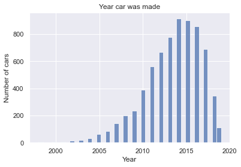

```python
# Histogram plot of the Year all the cars are made listed from data
plt.title("Year car was made")
sns.histplot(data=df, x="Year")
plt.ylabel("Number of cars")
plt.show()
```

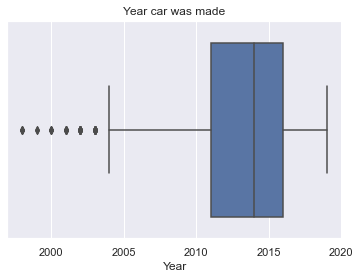

```python
# Boxplot of the Year all the cars are made
plt.title("Year car was made")
sns.boxplot(data=df, x="Year")
plt.show()
```

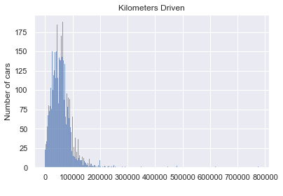

```python
# Histogram plot of the Kilometers_Driven from all cars in dataset
plt.title("Kilometers Driven")
sns.histplot(data=df, x="Kilometers_Driven", bins=500)
plt.xlabel(" ")
plt.ylabel("Number of cars")
plt.show()
```

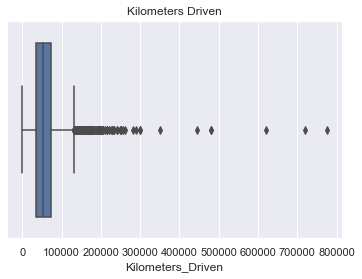

```python
# Boxplot of the Kilometers_Driven from all cars in dataset
plt.title("Kilometers Driven")
sns.boxplot(data=df, x="Kilometers_Driven")
plt.show()
```

- Histogram shows that the Kilometers Driven for all vehicles is right skewed
- The IQR is between 34,000 and 73,000 Kilometers with a mean of about 58,000 Kilometers
- The outliers are 130,000 Kilometers or more

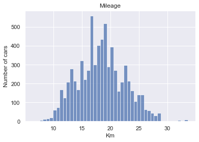

```python
# Histogram plot of the Mileage in Km from all cars in dataset
plt.title("Mileage")
sns.histplot(data=df, x="Mileage")
plt.xlabel("Km")
plt.ylabel("Number of cars")
plt.show()
```

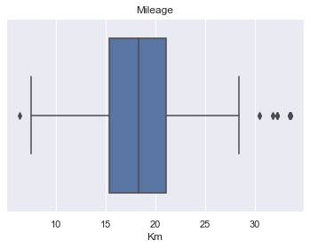

```python
# Boxplot of the Mileage in Km from all cars in dataset
plt.title("Mileage")
sns.boxplot(data=df, x="Mileage")
plt.xlabel("Km")
plt.show()
```

- Histogram shows that the Mileage in Kilometers for all vehicles is normal distribution
- The IQR is between 15 and 21 Kilometers with a mean of about 18 Kilometers
- The outliers are 28 Kilometers or more

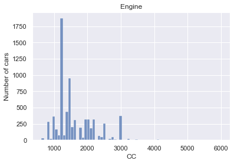

```python
# Histogram plot of the type Engine in CC from all cars in dataset
plt.title("Engine")
sns.histplot(data=df, x="Engine")
plt.xlabel("CC")
plt.ylabel("Number of cars")
plt.show()
```

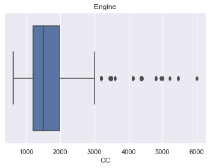

```python
# Boxplot of the type Engine in CC from all cars in dataset
plt.title("Engine")
sns.boxplot(data=df, x="Engine")
plt.xlabel("CC")
plt.show()
```

- Histogram shows that the Engine in CC for all vehicles is right skewed
- The IQR is between 1200 and 2000 CC with a mean of about 1600 CC
- The outliers are 3000 CC or more

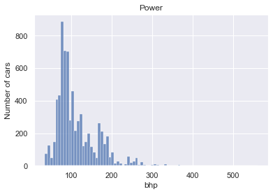

```python
# Histogram plot of the Power delivered in bhp from all cars in dataset
plt.title("Power")
sns.histplot(data=df, x="Power")
plt.xlabel("bhp")
plt.ylabel("Number of cars")
plt.show()
```

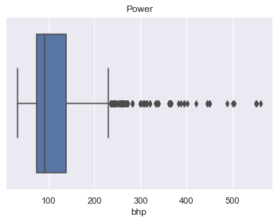

```python
# Boxplot of the Power delivered in bhp from all cars in dataset
plt.title("Power")
sns.boxplot(data=df, x="Power")
plt.xlabel("bhp")
plt.show()
```

- Histogram shows that the Power delivered in bhp for all vehicles is right skewed
- The IQR is between 75 and 140 bhp with a mean of about 112 bhp
- The outliers are 230 bhp or more

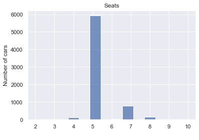

```python
# Histogram plot of the number of Seats for all cars in dataset
plt.title("Seats")
sns.histplot(data=df, x="Seats")
plt.xlabel(" ")
plt.ylabel("Number of cars")
plt.show()
```

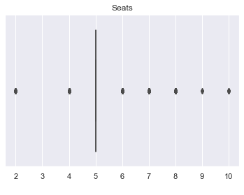

```python
# Boxplot of the number of Seats for all cars in dataset
plt.title("Seats")
sns.boxplot(data=df, x="Seats")
plt.xlabel(" ")
plt.show()
```

### We will probable treat Seats as a category using df2 dataset! We will see which dataset works best in our modeling.

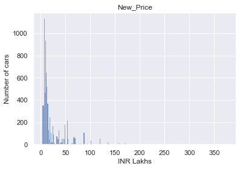

```python
# Histogram plot of the New Price of cars in our dataset
plt.title("New_Price")
sns.histplot(data=df, x="New_Price")
plt.xlabel("INR Lakhs")
plt.ylabel("Number of cars")
plt.show()
```

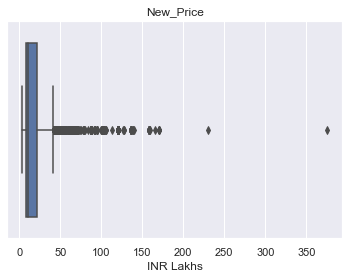

```python
# Boxplot of the New Price of cars in our dataset
plt.title("New_Price")
sns.boxplot(data=df, x="New_Price")
plt.xlabel("INR Lakhs")
plt.show()
```

```python
df[df["New_Price"] > 200]
```

|  | S.No. | Name | Location | Year | Kilometers_Driven | Fuel_Type | Transmission | Owner_Type | Mileage | Engine | Power | Seats | New_Price | Price |
| --- | --- | --- | --- | --- | --- | --- | --- | --- | --- | --- | --- | --- | --- | --- |
| 4053 | 4079 | Land Rover Range Rover 3.0 Diesel LWB Vogue | Hyderabad | 2017 | 25000 | Diesel | Automatic | First | 13.33 | 2993 | 255.0 | 5 | 230.0 | 160.0 |
| 5483 | 5521 | Bentley Continental Flying Spur | Hyderabad | 2006 | 48000 | Petrol | Automatic | First | 8.60 | 5998 | 552.0 | 4 | 375.0 | 59.0 |

- Histogram shows that the New Prices for all vehicles is extremely right skewed
- The IQR is between 8 and 21 INR Lakhs with a mean of about 21 INR Lakhs
- The outliers are 40 INR Lakhs or more
- The two big outliers seem to be just high price vehicles

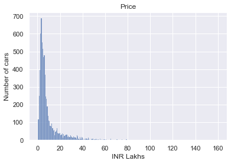

```python
# Histogram plot of the Used car Prices in our dataset
plt.title("Price")
sns.histplot(data=df, x="Price")
plt.xlabel("INR Lakhs")
plt.ylabel("Number of cars")
plt.show()
```

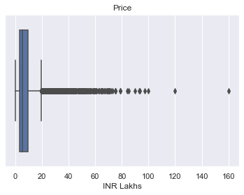

```python
# Boxplot of the Used car Prices in our dataset
plt.title("Price")
sns.boxplot(data=df, x="Price")
plt.xlabel("INR Lakhs")
plt.show()
```

- Histogram shows that the Used car Prices for all vehicles is extremely right skewed
- The IQR is between 4 and 10 INR Lakhs with a mean of about 9 INR Lakhs
- The outliers are 19.5 INR Lakhs or more

### Bivariate analysis:

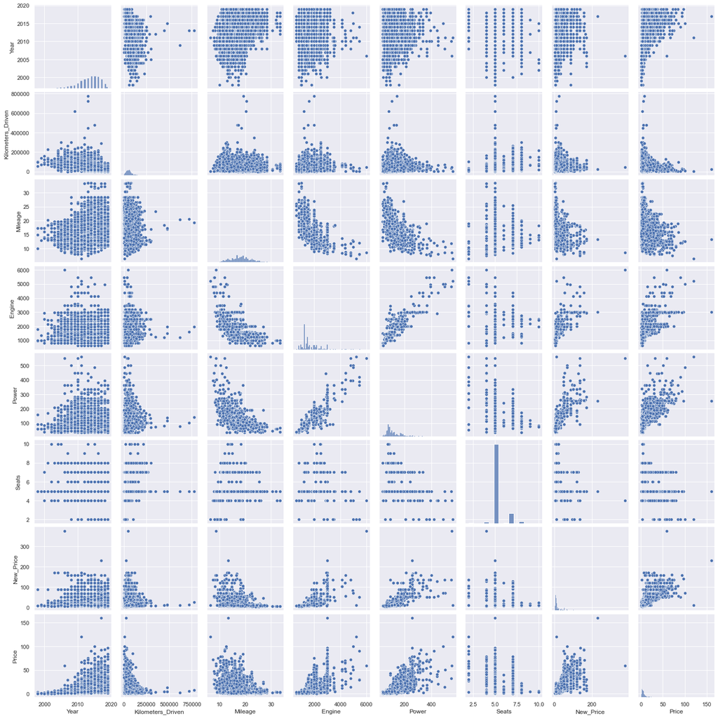

```python
# Pair plot of all the numerical values, check for correlation
sns.pairplot(
    data=df[
        [
            "Year",
            "Kilometers_Driven",
            "Mileage",
            "Engine",
            "Power",
            "Seats",
            "New_Price",
            "Price",
        ]
    ]
)
plt.show()
```

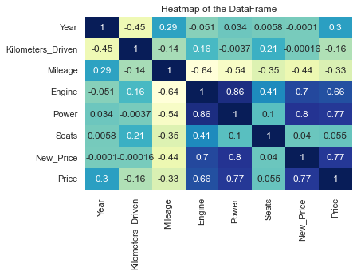

```python
# Heatmap showing the correlation of the different pairs
plt.title("Heatmap of the DataFrame")
sns.heatmap(
    data=df[
        [
            "Year",
            "Kilometers_Driven",
            "Mileage",
            "Engine",
            "Power",
            "Seats",
            "New_Price",
            "Price",
        ]
    ].corr(),
    annot=True,
    cbar=False,
    cmap="YlGnBu",
)
plt.show()
```

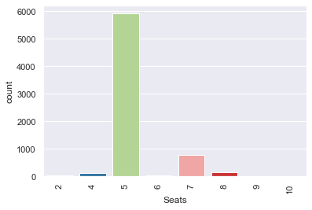

```python
# Barplot of the most popular seats configuration
plt.xticks(rotation=90)
sns.countplot(data=df, x="Seats", palette="Paired")
plt.show()
```

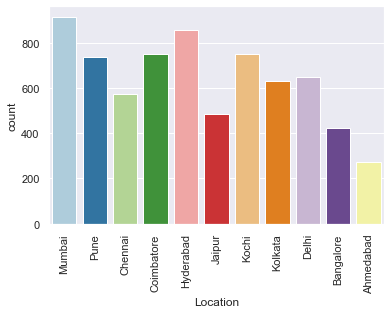

```python
# Barplot of the most popular Location cars are sold
plt.xticks(rotation=90)
sns.countplot(data=df, x="Location", palette="Paired")
plt.show()
```

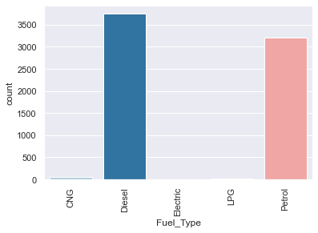

```python
# Barplot of the most popular fuel types
plt.xticks(rotation=90)
sns.countplot(data=df, x="Fuel_Type", palette="Paired")
plt.show()
```

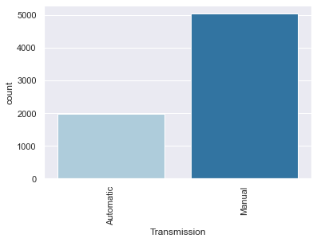

```python
# Barplot of the most popular Transmission configuration
plt.xticks(rotation=90)
sns.countplot(data=df, x="Transmission", palette="Paired")
plt.show()
```

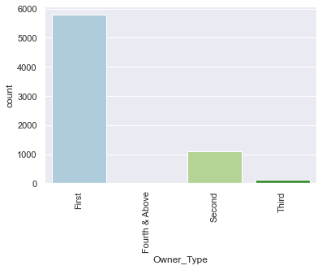

```python
# Barplot of the most popular ownership type
plt.xticks(rotation=90)
sns.countplot(data=df, x="Owner_Type", palette="Paired")
plt.show()
```

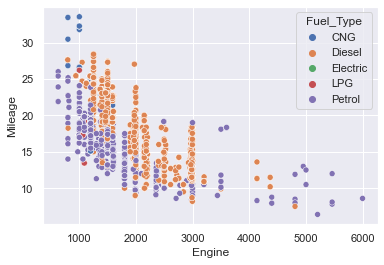

```python
# Scatter plot of comparing Engine and Mileage with Fuel Type
sns.scatterplot(data=df, x="Engine", y="Mileage", hue="Fuel_Type")
plt.show()
```

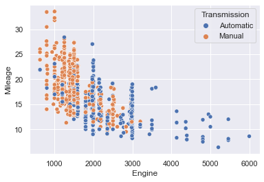

```python
# Scatter plot of comparing Engine and Mileage with Transmission
sns.scatterplot(data=df, x="Engine", y="Mileage", hue="Transmission")
plt.show()
```

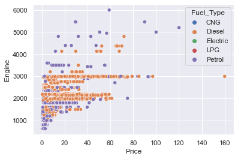

```python
# Scatter plot of comparing Price and Engine with Fuel Type
sns.scatterplot(data=df, x="Price", y="Engine", hue="Fuel_Type")
plt.show()
```

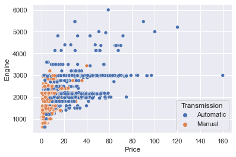

```python
# Scatter plot of comparing Price and Engine with Transmission
sns.scatterplot(data=df, x="Price", y="Engine", hue="Transmission")
plt.show()
```

## Key observations and relationships:

- New price of vehicle has a high positive correlation to Used prices
- Both Engine and Power has a high positive correlation to New and Used prices
- There is a positive correlation between Year of vehicle and used car prices
- There is a positive correlation between Engine size and the number of seats
- There is a positive correlation between Year of vehicle and the Mileage it can get
- There is a negitive correlation between Mileage and the cost of New and Used prices
- There is a negitive correlation between Mileage and Engine size in vehicle
- There is a negitive correlation between Mileage and Power output in vehicle
- There is a negitive correlation between Mileage and number of seats in vehicle
- There is a negitive correlation between Year of vehicle and the Kilometers driven
- Histogram shows that the Year in dataset are left skewed
- Histogram shows that the Engine in CC for all vehicles is right skewed
- Histogram shows that the Power delivered in bhp for all vehicles is right skewed
- Histogram shows that the Mileage in Kilometers for all vehicles is of normal distribution
- Histogram shows that the Kilometers Driven for all vehicles is right skewed
- Histogram shows that the New Prices for all vehicles is extremely right skewed
- Histogram shows that the Used car Prices for all vehicles is extremely right skewed
- Five Seats in vehicle is the most popular seats configuration
- Mumbai is the most popular location which vehicles are sold
- Diesel followed by petroleum is the most common fuel type
- Manual is the most common transmission type
- First is the most common ownership type
- Natural gas vehicles are small Engines with best Mileage
- Manual transmission in general get better Mileage
- The biggest Engines in this dataset run on petroleum
- The biggest Engines have Automatic transmission
- Higher priced vehicles have Automatic transmission
- Cheaper priced vehicles have manual transmission

# Model building - Linear Regression:

### Function for the Statistics about our models preformance

```python
# function to compute different metrics to check performance of a regression model
def model_performance_regression(model, predictors, target):
    """
    Function to compute different metrics to check regression model performance

    model: regressor
    predictors: independent variables
    target: dependent variable
    """

    # predicting using the independent variables
    pred = model.predict(predictors)

    r2 = r2_score(target, pred)  # to compute R-squared
    mae = mean_absolute_error(target, pred)  # to compute MAE
    rmse = np.sqrt(mean_squared_error(target, pred))  # to compute RMSE

    # creating a dataframe of metrics
    df_perf = pd.DataFrame({"R-squared": r2, "MAE": mae, "RMSE": rmse}, index=[0],)

    return df_perf
```

### We will now drop the `S.No.`, `Name`, and `Location` columns.

```python
df.drop(["S.No.", "Name", "Location"], axis=1, inplace=True)
```

```python
df2.drop(["S.No.", "Name", "Location"], axis=1, inplace=True)
```

### Create Dummy Variables

```python
df = pd.get_dummies(
    df, columns=["Fuel_Type", "Transmission", "Owner_Type"], drop_first=True
)
df.head()
```

|  | Year | Kilometers_Driven | Mileage | Engine | Power | Seats | New_Price | Price | Fuel_Type_Diesel | Fuel_Type_Electric | Fuel_Type_LPG | Fuel_Type_Petrol | Transmission_Manual | Owner_Type_Fourth & Above | Owner_Type_Second | Owner_Type_Third |
| --- | --- | --- | --- | --- | --- | --- | --- | --- | --- | --- | --- | --- | --- | --- | --- | --- |
| 0 | 2010 | 72000 | 26.60 | 998 | 58.16 | 5 | 5.51 | 1.75 | 0 | 0 | 0 | 0 | 1 | 0 | 0 | 0 |
| 1 | 2015 | 41000 | 19.67 | 1582 | 126.20 | 5 | 16.06 | 12.50 | 1 | 0 | 0 | 0 | 1 | 0 | 0 | 0 |
| 2 | 2011 | 46000 | 18.20 | 1199 | 88.70 | 5 | 8.61 | 4.50 | 0 | 0 | 0 | 1 | 1 | 0 | 0 | 0 |
| 3 | 2012 | 87000 | 20.77 | 1248 | 88.76 | 7 | 11.27 | 6.00 | 1 | 0 | 0 | 0 | 1 | 0 | 0 | 0 |
| 4 | 2013 | 40670 | 15.20 | 1968 | 140.80 | 5 | 53.14 | 17.74 | 1 | 0 | 0 | 0 | 0 | 0 | 1 | 0 |

### Split Data

```python
# Build our linear model
# Independant variables
X = df.drop(["Price"], axis=1)
# Dependent variable
y = df[["Price"]]
```

```python
# Split X and y into training and test set in 70:30 ratio

X_train, X_test, y_train, y_test = train_test_split(
    X, y, test_size=0.30, random_state=1
)
```

### Fit Linear Model

```python
# Create the model
regression_model = LinearRegression()
regression_model.fit(X_train, y_train)
```

```
LinearRegression()
```

```python
# checking the r^2 score for our train model
regression_model.score(X_train, y_train)
```

```
0.7561474359857061
```

```python
# Checking model performance on train set
print("Training Performance\n")
lin_reg_model_train_perf = model_performance_regression(
    regression_model, X_train, y_train
)
lin_reg_model_train_perf
```

```
Training Performance
```

|  | R-squared | MAE | RMSE |
| --- | --- | --- | --- |
| 0 | 0.756147 | 3.079241 | 5.442089 |

```python
# out of sample test score (R^2)
regression_model.score(X_test, y_test)
```

```
0.7428853141301814
```

```python
# Checking model performance on test set
print("Training Performance\n")
lin_reg_model_train_perf = model_performance_regression(
    regression_model, X_test, y_test
)
lin_reg_model_train_perf
```

```
Training Performance
```

|  | R-squared | MAE | RMSE |
| --- | --- | --- | --- |
| 0 | 0.742885 | 3.027097 | 5.452585 |

### - Using df2 which uses Seats as a category to see if it preforms better than df:

### Create Dummy Variables

```python
df2 = pd.get_dummies(
    df2, columns=["Fuel_Type", "Transmission", "Owner_Type", "Seats"], drop_first=True
)
df2.head()
```

|  | Year | Kilometers_Driven | Mileage | Engine | Power | New_Price | Price | Fuel_Type_Diesel | Fuel_Type_Electric | Fuel_Type_LPG | Fuel_Type_Petrol | Transmission_Manual | Owner_Type_Fourth & Above | Owner_Type_Second | Owner_Type_Third | Seats_4 | Seats_5 | Seats_6 | Seats_7 | Seats_8 | Seats_9 | Seats_10 |
| --- | --- | --- | --- | --- | --- | --- | --- | --- | --- | --- | --- | --- | --- | --- | --- | --- | --- | --- | --- | --- | --- | --- |
| 0 | 2010 | 72000 | 26.60 | 998 | 58.16 | 5.51 | 1.75 | 0 | 0 | 0 | 0 | 1 | 0 | 0 | 0 | 0 | 1 | 0 | 0 | 0 | 0 | 0 |
| 1 | 2015 | 41000 | 19.67 | 1582 | 126.20 | 16.06 | 12.50 | 1 | 0 | 0 | 0 | 1 | 0 | 0 | 0 | 0 | 1 | 0 | 0 | 0 | 0 | 0 |
| 2 | 2011 | 46000 | 18.20 | 1199 | 88.70 | 8.61 | 4.50 | 0 | 0 | 0 | 1 | 1 | 0 | 0 | 0 | 0 | 1 | 0 | 0 | 0 | 0 | 0 |
| 3 | 2012 | 87000 | 20.77 | 1248 | 88.76 | 11.27 | 6.00 | 1 | 0 | 0 | 0 | 1 | 0 | 0 | 0 | 0 | 0 | 0 | 1 | 0 | 0 | 0 |
| 4 | 2013 | 40670 | 15.20 | 1968 | 140.80 | 53.14 | 17.74 | 1 | 0 | 0 | 0 | 0 | 0 | 1 | 0 | 0 | 1 | 0 | 0 | 0 | 0 | 0 |

### Split Data

```python
# Build our linear model
# Independant variables
X = df2.drop(["Price"], axis=1)
# Dependent variable
y = df2[["Price"]]
```

```python
# Split X and y into training and test set in 70:30 ratio

X_train, X_test, y_train, y_test = train_test_split(
    X, y, test_size=0.30, random_state=1
)
```

### Fit Linear Model

```python
# Create the model
regression_model_2 = LinearRegression()
regression_model_2.fit(X_train, y_train)
```

```
LinearRegression()
```

```python
# checking the r^2 score for our train model
regression_model_2.score(X_train, y_train)
```

```
0.7651763363172887
```

```python
# Checking model performance on train set
print("Training Performance\n")
lin_reg_model_train_perf_2 = model_performance_regression(
    regression_model_2, X_train, y_train
)
lin_reg_model_train_perf_2
```

```
Training Performance
```

|  | R-squared | MAE | RMSE |
| --- | --- | --- | --- |
| 0 | 0.765176 | 3.027174 | 5.340389 |

```python
# out of sample test score (R^2)
regression_model_2.score(X_test, y_test)
```

```
0.7591867851942274
```

```python
# Checking model performance on test set
print("Training Performance\n")
lin_reg_model_train_perf_2 = model_performance_regression(
    regression_model_2, X_test, y_test
)
lin_reg_model_train_perf_2
```

```
Training Performance
```

|  | R-squared | MAE | RMSE |
| --- | --- | --- | --- |
| 0 | 0.759187 | 2.958661 | 5.276904 |

## - The model preformed better when we use "Seats" as a category!

## Variable Transformations:

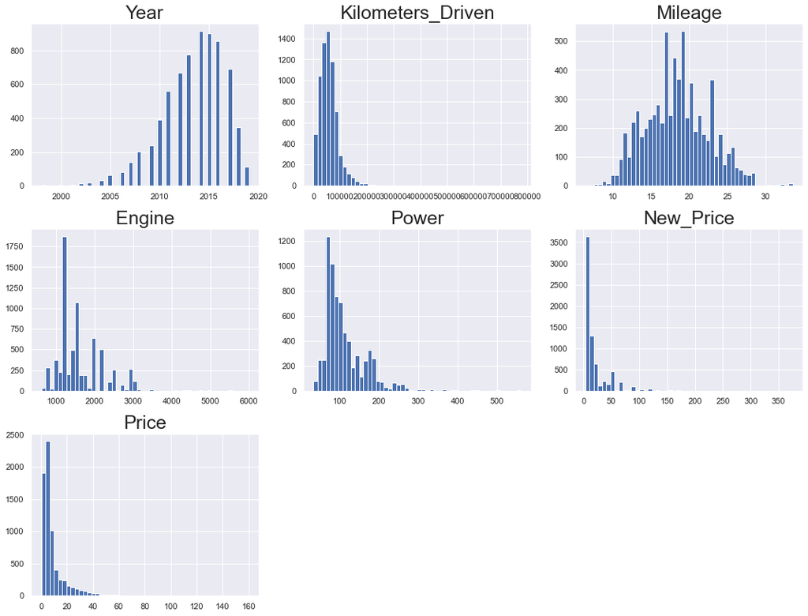

```python
# creating a list of non-category columns
dist_cols = [
    item
    for item in df2.select_dtypes(include=np.number).columns
    if "Seats" not in item
    if "Fuel_Type" not in item
    if "Transmission" not in item
    if "Owner_Type" not in item
]

# let's plot a histogram of all non-category columns
plt.figure(figsize=(15, 45))
for i in range(len(dist_cols)):
    plt.subplot(12, 3, i + 1)
    plt.hist(df2[dist_cols[i]], bins=50)
    plt.tight_layout()
    plt.title(dist_cols[i], fontsize=25)
plt.show()
```

- We see that most of the columns have a very skewed distribution.
- **We will apply the log transformation to all but the Mileage and Year columns to deal with skewness in the data.**

```python
# creating a copy of the dataframe
df3 = df2.copy()

# Removing the Mileage column as it is almost normally distributed
dist_cols.remove("Mileage")
# Removing the Year column as log transformation will not help this distribution
dist_cols.remove("Year")
```

```python
# Using log transforms to change all but Mileage column
for col in dist_cols:
    df3[col + "_log"] = np.log(df3[col] + 1)

# dropping the original columns
df3.drop(dist_cols, axis=1, inplace=True)
```

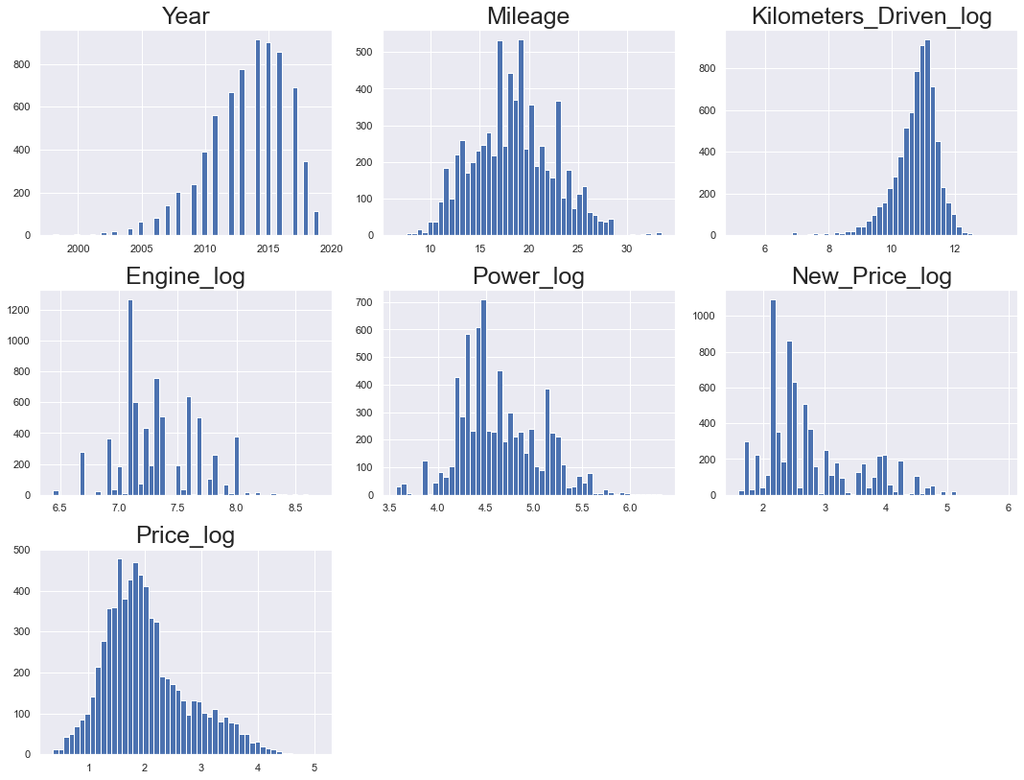

```python
# creating a list of non-category columns
dist_cols = [
    item
    for item in df3.select_dtypes(include=np.number).columns
    if "Seats" not in item
    if "Fuel_Type" not in item
    if "Transmission" not in item
    if "Owner_Type" not in item
]

# let's plot a histogram of all non-category columns
plt.figure(figsize=(15, 45))
for i in range(len(dist_cols)):
    plt.subplot(12, 3, i + 1)
    plt.hist(df3[dist_cols[i]], bins=50)
    plt.tight_layout()
    plt.title(dist_cols[i], fontsize=25)
plt.show()
```

### Split Data

```python
# Build our linear model
# Independant variables
X = df3.drop(["Price_log"], axis=1)
# Dependent variable
y = df3[["Price_log"]]
```

```python
# Split X and y into training and test set in 70:30 ratio

X_train, X_test, y_train, y_test = train_test_split(
    X, y, test_size=0.30, random_state=1
)
```

### Fit Linear Model

```python
# Create the model
regression_model_3 = LinearRegression()
regression_model_3.fit(X_train, y_train)
```

```
LinearRegression()
```

```python
# checking the r^2 score for our train model
regression_model_3.score(X_train, y_train)
```

```
0.9089100724595268
```

```python
# Checking model performance on train set
print("Training Performance\n")
lin_reg_model_train_perf_3 = model_performance_regression(
    regression_model_3, X_train, y_train
)
lin_reg_model_train_perf_3
```

```
Training Performance
```

|  | R-squared | MAE | RMSE |
| --- | --- | --- | --- |
| 0 | 0.90891 | 0.173848 | 0.225352 |

```python
# out of sample test score (R^2)
regression_model_3.score(X_test, y_test)
```

```
0.889373602667222
```

```python
# Checking model performance on test set
print("Training Performance\n")
lin_reg_model_train_perf_3 = model_performance_regression(
    regression_model_3, X_test, y_test
)
lin_reg_model_train_perf_3
```

```
Training Performance
```

|  | R-squared | MAE | RMSE |
| --- | --- | --- | --- |
| 0 | 0.889374 | 0.176684 | 0.242438 |

# Conclusions: